# Cómo el Lenguaje Afecta Nuestras Emociones: Clasificación de Historias de Terror

Authors

Mateo Yañez-Tanaka

Jorge Sánchez-Ponce

Fernando Ramos-Valdez

Fernando Pavía-González

## Introducción

El lenguaje que utilizamos al narrar historias refleja no solo información sobre los eventos que describimos, sino también patrones estructurales, elecciones léxicas y tonos emocionales que construyen la experiencia del lector. En el contexto de relatos de terror, estas características se vuelven particularmente relevantes, pues las palabras elegidas, las combinaciones sintácticas y la frecuencia de ciertos términos pueden diferenciar categorías de historias y moldear la percepción del lector.

Este proyecto se centra en el análisis cuantitativo del lenguaje en relatos de terror, utilizando técnicas de procesamiento de texto y aprendizaje automático para identificar patrones lingüísticos que distinguen entre historias sobre posesiones y exorcismos y aquellas sobre poltergeists y manifestaciones físicas. Se eligeron únicamente estas dos categrías debido a que estos tipos de eventos son conceptualmente bastante similares y diferenciar entre ellos podría ayudar a notar especificidades en el uso del lenguage. Se espera que con los resultados obtenidos por esta investigación se comprenda mejor como el lenguaje utilizado informa lo que se comunica y se encuentren correlaciones entre ciertos términos y la razón de la historia.

Investigaciones previas (Bohrn, Menninghaus, and Jacobs 2025)han mostrado que existen diferencias cognitivas reales en cómo los lectores procesan las narrativas con elementos sobrenaturales frente a las realistas. En la primera instancia se se ve activado mayormente el córtex sensoriomotor, el cual se encarga del aspecto de simulaciones motoras y perceptuales, por otro lado, el giro frontal inferior recibió mayor estimulación al momento de leer relatos con personajes realistas. Lo que esto indica es una diferencia respecto al uso del lenguaje, (El-Sayed 2021)a través del empleo de recursos literarios, como son metáforas relacionadas con alguna transformación física, referencias a la posesión (objetos o seres vivos), y en ciertos casos violencia, por tal motivo, la creación de un clasificador resulta pertinente y adecuado dado que sí se presentan variaciones reales en la literatura. En las siguientes secciones se presentan y describen los métodos utilizados, los resultados obtenidos y su interpretación en el entorno literario.

## Metodología

Para este proyecto se utilizaron las redes bayesianas (BN) para generar un clasificador de Naïve Bayes. Este clasificador asume que el único nodo padre en el sistema es la clase y loos nodos hijos el resto de variables. También se asume que los nodos hijos no se relacionan entre ellos, esto genera una estructura del estilo

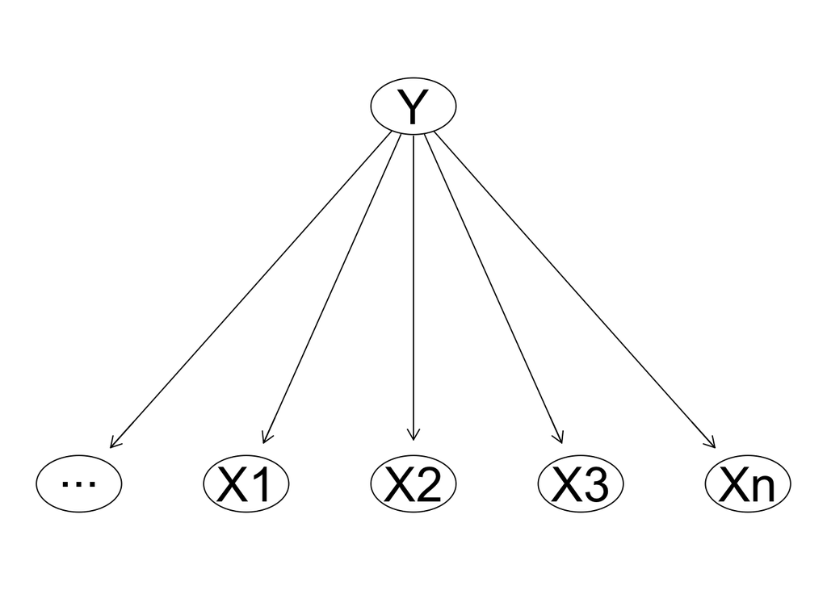

y nos permite generar la función de distribución global condicional
$$f(y,x_1,x_2,\ldots, x_n) = f(y)\prod_{i=1}^nf_i(x_i\mid y)$$
Este tipo de red tamién nos permite clasificar usando la regla de bayes en la cuál para una nueva observación $\tilde{x}$ la probabilidad de
$$\mathbb{P}(Y=k \mid X=\tilde{x}) = \frac{\mathbb{P}(X = \tilde{x} \mid Y=k)\mathbb{P}(Y=k)}{\mathbb{P}(X=\tilde{x})}$$
donde $\mathbb{P}(x) = \sum_{1}^k \mathbb{P}(X= \tilde{x} \mid Y= k)\mathbb{P}(Y=k)$. La clase asignada a cada observación es aquella con la mayor probabilidad a posteriori (Guillén 2025)

Este proyecto también utilizó una técnica conocida como *web scrapping*, esta se refiere a recolectar datos de algún sitio web extrayendolos de su código fuente (usualmente html). (ParseHub 2020) Aunado a esto se utilizó una técnica de *tokenización* (asignación de valores numéricos a palabras) conocida como *count vectorizer* que consiste en transformar el texto en una matriz donde cada palabra única se convierte en una columna y cada documento en una fila. El valor numérico asignado a cada palabra corresponde a la cantidad de veces que aparece en ese documento. Finalmente se usaron técnicas de eliminación de *stop words* (palabras que no añaden información) para mantener únicamente las palabras que añaden al texto.(Bansal 2018)

Todos los modelos computacionales usados para este proyecto fueron creados usando R un lenguaje de proggramacion para análisis estadístico. Se utilizaron los siguientes módulos: - `tidyverse` Para manipulación de datos - `tidytext` Para procesamiento de lenguaje natural - `tidymodels` Para preprocesamiento de datos - `tidyr` Para limpiar datos - `rvest` Para realizar el *web scraping* - `knitr` Para generar tablas y reportes dinámicos - `dplyr` Para manipulación de datos - `robotstxt` Para verificar que este permitido hacer *web scraping* en un sitio - `bnlearn` Para modelar usando redes bayesianas - `textdata` Para tareas de procesamiento de lenguaje natural - `e1071` Para modelos de *machine learning*

## Aplicación

Para este proyecto se utilizaron las historias de terror contenidas en [*Your Ghost Stories*](https://www.yourghoststories.com/real-ghost-stories.php). Se decidió que se trataría únicamente con dos tipos de historias, aquellas que son sobre demonios, posesiones y exorcismos y aquellas que son sobre poltergeists y manifestaciones físicas. Para generar los datos que se usaron para el clasificador se hizo una técnica conocida como *web scraping* que nos permite recolectar el texto que contiene una página web y se recolectaron únicamente las descripciones, el tipo de historia del que se trata, el lugar donde ocurrió y el título del relato. Se recolectaron 200 histarias en total, 100 de cada categoría de modo que los datos estuvieran balnaceados.

Después de aplicar esta técnica se realizó un proceso conocido como *count vectorizer*. Este consiste en transformar el texto en una matriz donde cada palabra única se convierte en una columna y cada documento en una fila. El valor numérico asignado a cada palabra corresponde a la cantidad de veces que aparece en ese documento. Adicionalmente, se eliminaron palabras comunes como *“the”*, *“in”*, *“of”*, y otras que no aportan información relevante a la historia.

### Análisis de Texto

Tras haberle aplicado este proceso a los datos, se realizó un análisis del texto contenido en cada historia. Se comenzó por oservar las diez palabras más frecuentes en cada una para ver si es un buen indicador en las diferentes categorías. Este anáisis permitió notar lo siguiente: cada relato está marcado por vocablos específicos que refuerzan su temática y contexto narrativo. Por ejemplo, en *“A Camp To Remember”* destacan términos como *“sheena”*, *“ate”* y *“camp”*, que aluden directamente al escenario y protagonistas; en *“Clash Of Personalities”* predominan *“apartment”*, *“door”* y *“porch”*, que sitúan el relato en un entorno doméstico; mientras que en *“A Future Fall”* resaltan palabras como *“church”*, *“demon”* y *“graveyard”*, asociadas a lo religioso y lo sobrenatural. En conjunto, estos patrones sugieren que las palabras poco comunes funcionan como anclajes semánticos que construyen la atmósfera de cada historia, diferenciándolas entre sí y enfatizando elementos centrales (lugares, personajes o conceptos sobrenaturales) que definen el tono y la experiencia narrativa de lo paranormal.

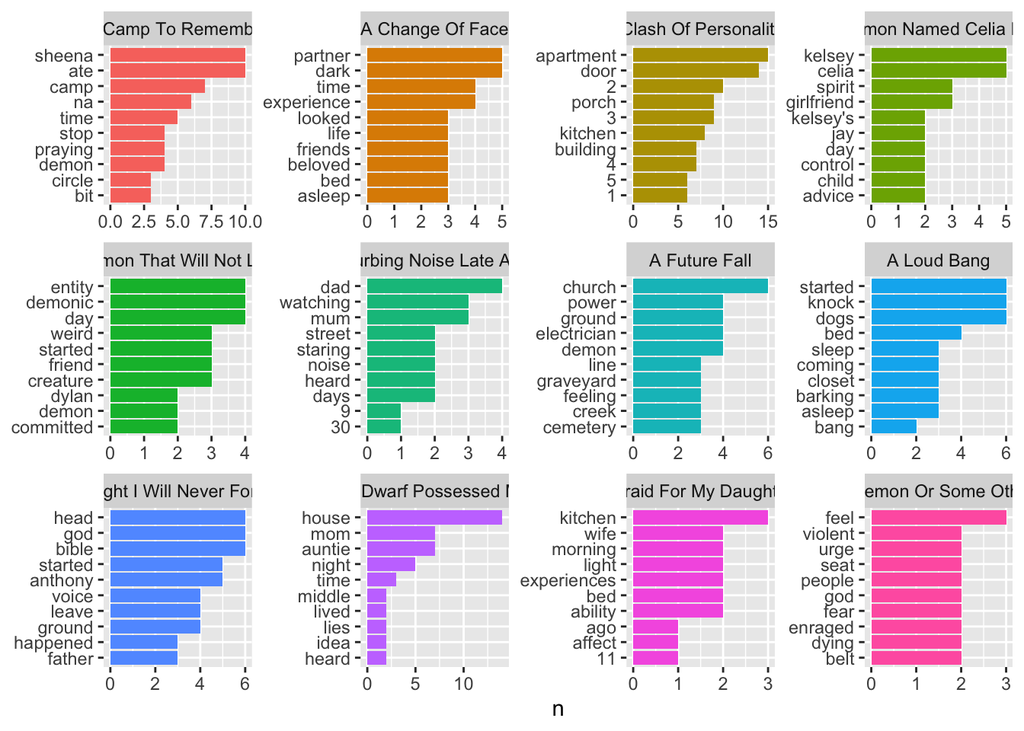

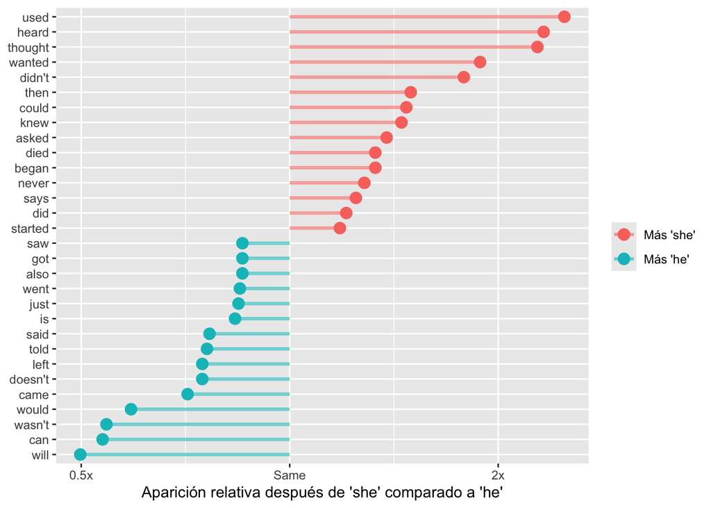

Finalmente se anlaizó cómo las palabras determinan los sentimientoos implicados por una historia. Para esto se le asignó un valor numérico a cada una de las palabras representando su connotación emocional. El tono de cada historia fue considerado como la suma de los valores sentimentales de sus palabras. Este análisis mostró que la mayoría de las historias son significativamente más negativas que positivas con solo 20 títulos siendo mayormente positivos o neutros. Debido a la materia de las historias que se analizaron, resultados de este índole eran de esperarse, las historias de terror tienden a ser bastante negativas y esto se exalta cuando se habla de posesiones, demonios, exorcismos, poltergeists y manifestaciones físicas.

| story_id | sentiment_score |
| --- | --- |
| Spirits Can Become Members Of Your Family | 22 |
| End Of Paranormal Activities | 21 |
| That Evil Smile | 13 |
| It Likes My Singing | 7 |
| Demon: For Real Or Just A Dream? | 6 |
| My First Sighting Of A Demon | 5 |
| Did An Evil Spirit Take Me Over? | 3 |
| I Think My Boyfriend Is Possessed | 2 |
| My First Paranormal Experience: Possesion | 2 |
| Mysterious Poltergiest In My Room | 2 |
| Sapi (possession) | 2 |
| The Water Spirit Or Jala Pishach | 2 |
| Floating Above My Bed | 1 |
| Friendly Little Charlie | 1 |
| My Three Unexplainable Ghost Experiences | 1 |
| Am I Possessed? | 0 |
| Basement Movement | 0 |
| Demonic Possession | 0 |
| Flying Flowers Broken Vase | 0 |
| How Do I Get Rid Of Black Magic That’s Been Done On My Body? | 0 |
| A Tired Dwarf Possessed My Aunt | -1 |
| Clean Clothes Dumped On The Floor | -1 |
| Evil Jinn | -1 |
| Ghostly Attack | -1 |
| My Teddy And The Doors | -2 |
| The Beginning Of It All | -2 |
| The Titanic Exhibit And The Broken Toy | -2 |
| Missing Things | -3 |
| Multiple Experiences In One House | -3 |
| One Crazy Night | -3 |

[output cut: 170 more lines]

### Clasificación de Textos

Con los textos analizados se utilizó el moodelo de clasifación conocido como *Naïve Bayes* para categorizar historias nuevas en alguno de los eventos que incluimos (posesiones exorcismos y demonios o poltergeists y manifestaciones físicas). Para entrenar este modelo se dividieron los datos en 80% para entrenamiento y 20% para pruebas. Este modelo resultó en la siguiente matriz de confusión

```
                                        ValoresReales
Predecido                                Demons / Possessions / Exorcisms
  Demons / Possessions / Exorcisms                                     16
  Poltergeists / Physical Manifestations                                4
                                        ValoresReales
Predecido                                Poltergeists / Physical Manifestations
  Demons / Possessions / Exorcisms                                            2
  Poltergeists / Physical Manifestations                                     18
```

En esta se da a notar la capacidad de predicción del modelo con un total de 34 predicciones correctas de un total de 40 historias usadas para probar. Aunado a esto se calcularon los siguientes puntajes:

|  | accuracy | recall | precision |
| --- | --- | --- | --- |
| Demons / Possessions / Exorcisms | 0.85 | 0.8 | 0.8888889 |
| Poltergeists / Physical Manifestations | 0.85 | 0.9 | 0.8181818 |

El modelo presenta una exactitud (*accuracy*) de 85% siendo bastante bueno. Presenta una exhaustividad (*recall*) de 80% y 90% respectivamente lo cual evoca que no predice ninguna clase desproporcionadamente. Finalmente presenta precisiones de 89% y 82% por lo que se puede inferir que el valor de predicciones positivas se acercó mucho al real sustentando la aseveración de que no sobrepredice ninguna clase.

## References

Bansal, Shivam. 2018. “Understanding Count Vectorizer.” 2018. https://medium.com/swlh/understanding-count-vectorizer-5dd71530c1b.

Bohrn, Isabel C., Winfried Menninghaus, and Arthur M. Jacobs. 2025. “Neural Mechanisms of Supernatural Fiction.” *Npj Science of Learning* 10 (1): 1–11. https://doi.org/10.1038/s41539-025-00327-0.

El-Sayed, Wesam. 2021. “Language Performativity and Horror Fiction: The Case of Possession.” *International Journal of Language and Literary Studies* 3 (3): 130–45. https://doi.org/10.36892/ijlls.v3i3.647.

Guillén, Javier E. Garrido. 2025. “Módulo 3: Clasificadores de Redes Bayesianas.” Análisis de métodos de razonamiento e incertidumbre, Gpo 102 - AD 2025.

ParseHub. 2020. “What Is Web Scraping?” 2020. https://www.parsehub.com/blog/what-is-web-scraping/.